# Laboratório 5 - Relação entre Beleza e Pontuação dos professores

Vários cursos universitários dão aos alunos a oportunidade de avaliar o curso e o professor de maneira anônima ao final do semestre. Contudo, o uso das avaliações dos alunos como um indicador da qualidade do curso e a eficácia do ensino é frequentemente criticado porque essas medidas podem refletir a influência de características não relacionadas à docência, tal como a aparência física do professor. Neste laboratório analisaremos os dados de um estudo que coletou dados para examinar a hipótese de que a beleza do professor influencia na percepção de competência dos alunos.

Os dados foram coletados a partir das avaliações discentes de final de semestre de uma grande amostra de professores da Universidade do Texas em Austin. Além disso, seis estudantes avaliaram a aparência física dos professores. O resultado é um banco de dados no qual cada linha contém diferentes disciplinas e cada coluna representa as variáveis sobre as disciplinas e os professores. As variáveis contidas nele são as seguintes:

```r
avaliacao_professores = read_csv(here::here("data/evals.csv"))
```

```r
avaliacao_professores
```

```
## # A tibble: 463 x 21
##    score rank   ethnicity gender language   age cls_perc_eval cls_did_eval
##    <dbl> <chr>  <chr>     <chr>  <chr>    <int>         <dbl>        <int>
##  1  4.70 tenur… minority  female english     36          55.8           24
##  2  4.10 tenur… minority  female english     36          68.8           86
##  3  3.90 tenur… minority  female english     36          60.8           76
##  4  4.80 tenur… minority  female english     36          62.6           77
##  5  4.60 tenur… not mino… male   english     59          85.0           17
##  6  4.30 tenur… not mino… male   english     59          87.5           35
##  7  2.80 tenur… not mino… male   english     59          88.6           39
##  8  4.10 tenur… not mino… male   english     51         100.            55
##  9  3.40 tenur… not mino… male   english     51          56.9          111
## 10  4.50 tenur… not mino… female english     40          87.0           40
## # ... with 453 more rows, and 13 more variables: cls_students <int>,
## #   cls_level <chr>, cls_profs <chr>, cls_credits <chr>,
## #   bty_f1lower <int>, bty_f1upper <int>, bty_f2upper <int>,
## #   bty_m1lower <int>, bty_m1upper <int>, bty_m2upper <int>,
## #   bty_avg <dbl>, pic_outfit <chr>, pic_color <chr>
```

Com base nos dados, é possível observar que existem 463 registros de avaliações de professores. Cada avaliação conta com 21 variáveis analisada, como por exemplo o score do professor, que apresenta a pontuação média do professor variando de 1 (muito insatisfeito) a 5 (excelente), gender (sexo do professor), age (idade do professor), bty_avg (média da beleza do professor, varia entre 0 a 10 sendo baseada nas variáveis bty_f1lower, bty_f1upper, bty_f2upper, bty_m1lower, bty_m1upper e bty_m2upper, que representa a avaliação realizada por 6 alunos, no que diz respeito a beleza dos professores) e etc.

Essa análise manteve o foco principal em verificar o impacto das variáveis score, bty_avg, cls_level, cls_credits, cls_profs, cls_students, gender e age.

Na seção abaixo é apresentada os dados são explorados com mais detalhes.

## 1. Análise descritiva dos dados

Primeiramente analisamos a divisão dos professores por seu sexo. Assim, a tabela abaixo apresenta a quantidade de profissionais de educação do genêro feminino e masculino.

```r
avaliacao_professores %>%
  group_by(gender) %>%
  summarise(
    total_number =  n()
  )
```

```
## # A tibble: 2 x 2
##   gender total_number
##   <chr>         <int>
## 1 female          195
## 2 male            268
```

Com base ba Tabela acima, é possível identificar que existem mais professores do sexo masculino em comparação ao sexo feminino.

Ainda com objetivo de entender melhor os dados, as Tabelas abaixo foram produzidas. Nelas, estão presentes iformações sobre quantidade presente nos dados para as variável analisadas:

- *ethnicity:* Etnia do professor, variando entre minority (minoria) e not minority (não minoria);
- *cls_level:* Nível da disciplina variando entre lower (Introdutória) e upper (Avançada).
- *cls_credits:* Número de créditos da disciplina variando entre um crédito e múltiplos créditos.
- *cls_profs:* Número de professores minstrando módulos na disciplina dentro da amostra, variando entre único e multiplos.
- *cls_students:* Número de alunos na turma.
- *gender:* Sexo do professor, variando entre masculino e feminino.
- ***age:** Idade do professor.

```r
avaliacao_professores %>%
  group_by(ethnicity) %>%
  summarise(
    total_number =  n()
  )
```

```
## # A tibble: 2 x 2
##   ethnicity    total_number
##   <chr>               <int>
## 1 minority               64
## 2 not minority          399
```

```r
avaliacao_professores %>%
  group_by(pic_outfit) %>%
  summarise(
    total_number =  n()
  )
```

```
## # A tibble: 2 x 2
##   pic_outfit total_number
##   <chr>             <int>
## 1 formal               77
## 2 not formal          386
```

```r
avaliacao_professores %>%
  group_by(pic_color) %>%
  summarise(
    total_number =  n()
  )
```

```
## # A tibble: 2 x 2
##   pic_color   total_number
##   <chr>              <int>
## 1 black&white           78
## 2 color                385
```

```r
avaliacao_professores %>%
  group_by(rank) %>%
  summarise(
    total_number =  n()
  )
```

```
## # A tibble: 3 x 2
##   rank         total_number
##   <chr>               <int>
## 1 teaching              102
## 2 tenured               253
## 3 tenure track          108
```

```r
avaliacao_professores %>%
  group_by(cls_level) %>%
  summarise(
    total_number =  n()
  )
```

```
## # A tibble: 2 x 2
##   cls_level total_number
##   <chr>            <int>
## 1 lower              157
## 2 upper              306
```

```r
avaliacao_professores %>%
  group_by(cls_credits) %>%
  summarise(
    total_number =  n()
  )
```

```
## # A tibble: 2 x 2
##   cls_credits  total_number
##   <chr>               <int>
## 1 multi credit          436
## 2 one credit             27
```

Para analisar também a distribuição dos dados dos scores dos professores, a Figura 1 foi produzida.

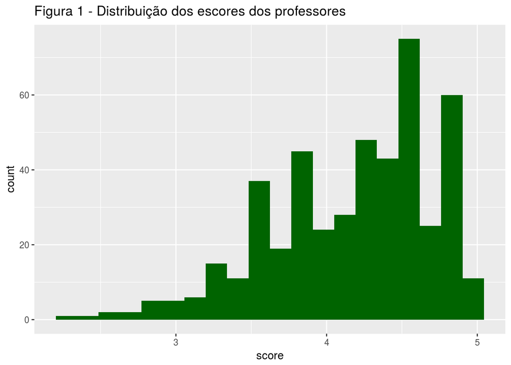

```r
avaliacao_professores %>%
  ggplot(aes(x = score)) +
  geom_histogram(bins = 20, fill = 'darkgreen') +
  labs(title="Figura 1 - Distribuição dos escores dos professores")
```

Para analisar como estão nos dados a distribuição da média da beleza dos professores, a Figura 2 foi construída

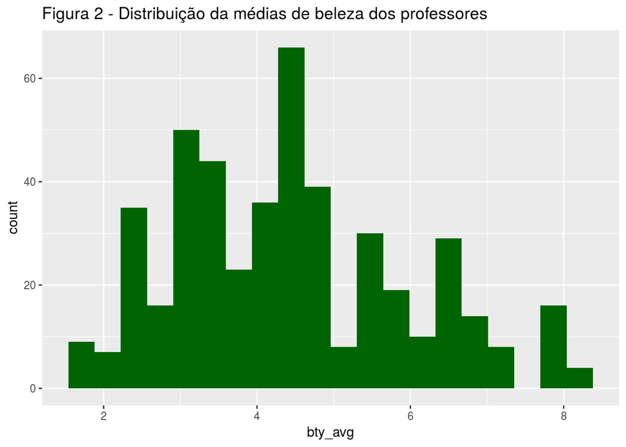

```r
avaliacao_professores %>%
  ggplot(aes(x = bty_avg)) +
  geom_histogram(bins = 20, fill = 'darkgreen') +
  labs(title="Figura 2 - Distribuição da médias de beleza dos professores")
```

Com base na Figura 2, é observado que maior parte dos professores possuem como média de beleza um valor 3 e 4.5 (4.3/4.4 maior concentração). No mais, podemos também analisar que não existem médias de belezas acima de 8.5 (médias possíveis são entre 0 a 10).

Para analisar a distribuição das faixas etárias dos professores, a Figura 3 foi construida.

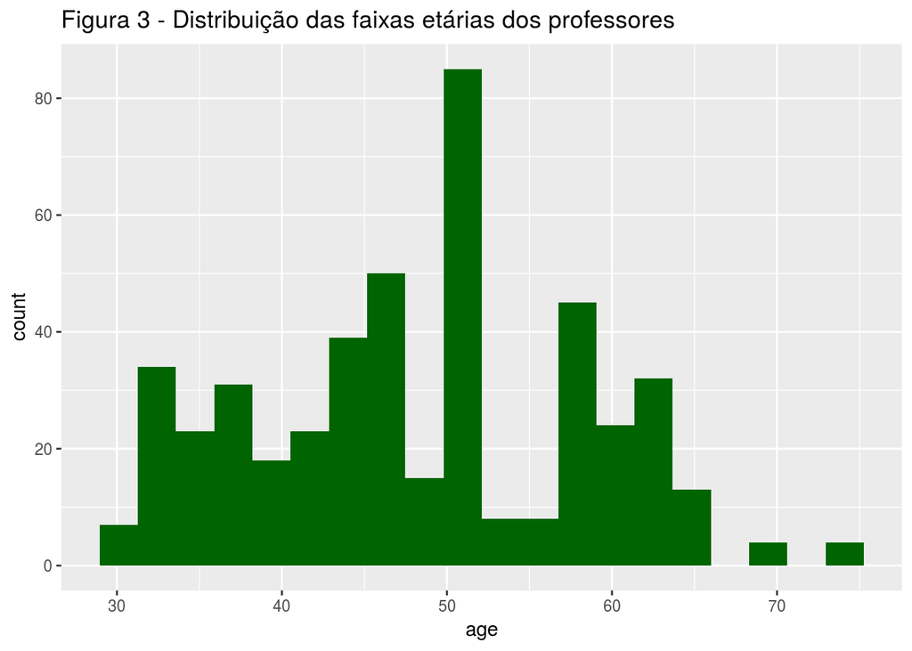

```r
avaliacao_professores %>%
  ggplot(aes(x = age)) +
  geom_histogram(bins = 20, fill = 'darkgreen') +
  labs(title="Figura 3 - Distribuição das faixas etárias dos professores")
```

No que diz respeito a tamanho das turmas dos professores avaliados, a Figura 4 apresenta a divisão amostral para esse aspecto.

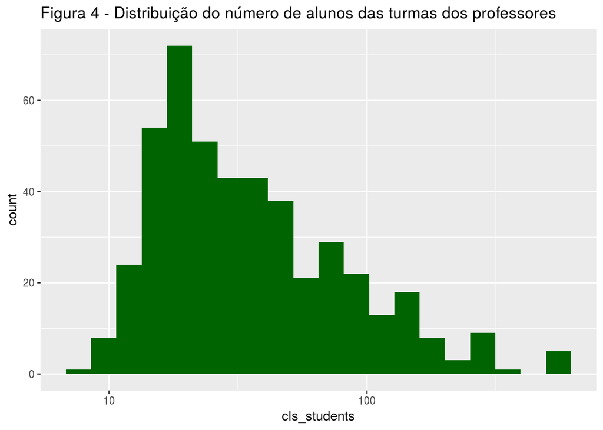

```r
avaliacao_professores %>%
  ggplot(aes(x = cls_students)) +
  geom_histogram(bins = 20, fill = 'darkgreen') +
  scale_x_log10()+
  labs(title="Figura 4 - Distribuição do número de alunos das turmas dos professores")
```

## 2. Relação entre score e beleza dos professores

Com objetivo de verificar existência de uma relação significância entre a beleza e o score dos professores, inicialmente foi verificado se havia uma relação direta entre a pontuação (score) e a beleza (bty_avg) dos professores. Deste modo, A Figura 6 foi produzida.

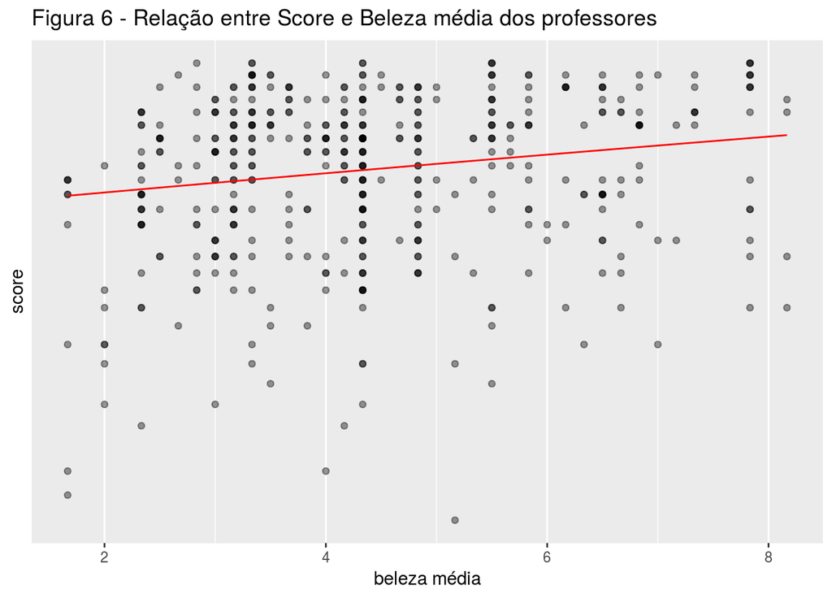

```r
modelo1 <- lm(score ~ bty_avg, data = avaliacao_professores)

avaliacao_professores %>%
  add_predictions(model = modelo1) %>%
  ggplot(aes(x = bty_avg, y = score)) +
  geom_point(alpha = 0.4) +
  scale_y_log10() +
  geom_line(aes(y = pred), colour = "red") +
  labs(title="Figura 6 - Relação entre Score e Beleza média dos professores", x = "beleza média")
```

Analisando a Figura 6, é identificável a existência de um pequeno aumento no score quando a média da beleza dos professores aumenta. Para verificar com mais detalhes esta relação, foi utilizada regressão simples e abaixo são apresentados os resultados obtidos por meio do uso da técnica.

```r
tidy(modelo1, conf.int = TRUE, conf.level = 0.95)
```

```
##          term   estimate  std.error statistic       p.value   conf.low
## 1 (Intercept) 3.88033795 0.07614297 50.961212 1.561043e-191 3.73070764
## 2     bty_avg 0.06663704 0.01629115  4.090382  5.082731e-05 0.03462292
##    conf.high
## 1 4.02996827
## 2 0.09865116
```

```r
glance(modelo1)
```

```
##    r.squared adj.r.squared     sigma statistic      p.value df    logLik
## 1 0.03502226    0.03292903 0.5348351  16.73123 5.082731e-05  2 -366.2225
##        AIC      BIC deviance df.residual
## 1 738.4449 750.8581 131.8684         461
```

Para analisar se beleza (média de avaliação de atributos físicos) tem uma associação significativa com os scores (pontuação obtida por avaliação de competências acadêmicas) dos professores, foi utilizada regressão simples. Os resultados indicam que um modelo com os 1 preditor no formato score = bty_avg explicam 3% da variância da variável de resposta (R2 = 0.03). A métrica beleza dos professores é o resultado da média de avaliações de atributos físicos dos professores pelos alunos, tendo uma relação significativa com o erro (b = [0.03; 0.09], IC com 95%). O aumento de 1 unidade na média da beleza produz uma mudança de 0.06 no score.

Nesse sentido, o modelo utilizado, conseguiu explicar apenas 3% da variância do score dos professores, o que demostra pouca relevância da variável bty_avg para o modelo utilizado.

Na próxima seção será analisado a relação de sigificância entre o score a outras variáveis.

## 3. idade e score professores

Considerando as variáveis cls_credits (Número de créditos da disciplina), cls_level (nível da disciplina), cls_profs (números de professores que ministram os diferentes módulos da disciplina), cls_students (número de estudantes na turma), ethnicity (etnia), gender (sexo) e age (idade), como valores que podem imapactar no score do professor, elas foram utilizadas como preditores para construção de um modelo, que verifica se estas variáveis apresentam relavância no que diz respeito ao score obtido pelos professores.

Para isso, as variáveis foram divididas em dois grupos. O primeiro grupo apresenta as variáveis que para esta análise foram consideradas de grande significância no valor obtido pelo score (variáveis mais relacionadas ao contexto acadêmico de ensino), e outro grupo com variáveis que podem ter relevância significativa, mas que não estão diretamente ligadas ao cenário acadêmico.

No grupo 1 foram consideradas as seguintes variáveis:

- *cls_credits:* Partindo da suposição de que disciplinas com mais créditos tendem a criarem um vinculo de convivio maior entre o professor e os alunos, e ainda que o professor lecionar por mais tempo em uma mesma turma em comparação a outros professores com disciplinas de menor crédito.
- *cls_level:* Partindo da suposição que disciplinas introdutórias possuem um nível mais baixo e que assim os alunos conseguem assimilar o conteúdo de uma maneira mais fácil.
- *cls_profs:* Partindo da suposição que quanto menor o número de professor que ministra uma disiciplina, melhor o nível de interação dos alunos e melhor o desempenho do professor.
- *cls_students:* Partindo da suposição que quanto menor a turma de alunos do professor, melhor a posibilidade de professor dar maior atenção a seus alunos durante as aulas.

Para o grupo 2 foram consideradas as seguintes variáveis

- *ethnicity:* Partindo da suposição que professores que possuem a etnia considerada minoria, podem ter algum tipo de dificuldade ao lecionar.
- *gender:* Partindo da suposição que sexo do professor pode ser relevante para idetificar alguma variância do score dos professores.
- *age:* Partindo da suposição que a idade do professor pode ser relevante para idetificar alguma variância do score dos professores.

Com base nessas suposições, foi construído um modelo de regressão multivariada para verificar se existe uma associação significativa entre as variáriveis apresentadas e o score dos professores. Abaixo são apresentados os resultados obtidos com este modelo.

```r
modelo2 <- lm(score ~ cls_credits + cls_level + cls_profs + cls_students + ethnicity + gender + age, data = avaliacao_professores)

tidy(modelo2, conf.int = TRUE, conf.level = 0.95) %>%  select(term, estimate, conf.low, conf.high)
```

```
##                    term      estimate      conf.low     conf.high
## 1           (Intercept)  4.2759455398  3.9979473075  4.5539437721
## 2 cls_creditsone credit  0.5348076027  0.3087527852  0.7608624202
## 3        cls_levelupper -0.0011351361 -0.1122777284  0.1100074563
## 4       cls_profssingle  0.0182187977 -0.0857480763  0.1221856716
## 5          cls_students  0.0001382412 -0.0005330291  0.0008095114
## 6 ethnicitynot minority  0.2101334603  0.0621572418  0.3581096788
## 7            gendermale  0.1591742959  0.0564323014  0.2619162904
## 8                   age -0.0086566873 -0.0137804533 -0.0035329213
```

```r
glance(modelo2) %>%  select(r.squared, adj.r.squared)
```

```
##    r.squared adj.r.squared
## 1 0.09288603    0.07893043
```

Os resultados da regressão indicam que um modelo com os 7 preditores no formato score = cls_credits + cls_level + cls_profs + cls_students + ethnicity + gender + age explicam 8% da variância da variável de resposta (R2 = 0.08). A variável cls_credits, tem uma relação significativa quando a disciplina só tem um crédito (o inverso da suposição criada) com o erro (b = [0.30; 0.76], IC com 95%), com o aumento de 0.5 em cada unidade do score. Já as demais variáveis do grupo 1 não apresentaram valores significativos para serem considerados. Assim, as variáveis cls_level, cls_profs e cls_students não são úteis para representação de significância para o modelo.

As variáveis do grupo 2, apresentaram relação significativa em relação ao o score dos professores. A variável ethnicity (considerando a não minoria) possuei um relação de relevância com score com erro (b = [0.06; 0.35], IC com 95%), onde a variável representa 0.21 do aumento em cada unidade do score. A variável gender (considerando o sexo masculino) apresentou uma relevância nessa relação com erro (b = [0.05; 0.26], IC com 95%), representando o aumento 0.16 no aumento de cada unidade do score. Em contrapartida a variável age (idade) mostrou um relação significativa negativa com escore, onde a variável mostra uma perda em cada unidade de score de 0.008.

Nesse contexto, removemos as variáveis que não se apresentaram significativas no modelo no que diz respeito a variância do score do professores.

```r
modelo2 <- lm(score ~ cls_credits + ethnicity + gender + age, data = avaliacao_professores)

tidy(modelo2, conf.int = TRUE, conf.level = 0.95) %>%  select(term, estimate, conf.low, conf.high)
```

```
##                    term     estimate    conf.low    conf.high
## 1           (Intercept)  4.293217297  4.03102021  4.555414383
## 2 cls_creditsone credit  0.526041940  0.31606671  0.736017171
## 3 ethnicitynot minority  0.206485125  0.06283209  0.350138160
## 4            gendermale  0.163190186  0.06204776  0.264332613
## 5                   age -0.008716352 -0.01379522 -0.003637481
```

```r
glance(modelo2) %>%  select(r.squared, adj.r.squared)
```

```
##    r.squared adj.r.squared
## 1 0.09234572     0.0844186
```

## 4. Conclusão

Nesse relatório, foi apresentado análise da relação da beleza (bty_avg) na variância do score dos professores. Os resultaram apontam que a média da beleza para modelo utilizado têm pouca influência na variável score, conseguindo explicar apensas cerca de 3% dessa variação. Dessa forma, partindo do pressuposto que existiam outros aspectos que eram mais relavantes para explicar o score dos professores, foi optado por investigar o impacto de variáveis do âmbito acadêmico como número de alunos da turma do professor e também variáveis mais gerais como sexo e idade dos professores. Por fim, foi construído um modelo de regressão multivariada que apresentou um explicação de 9% da variância do score dos professores.

Com base nesses, resultados é possível concluir que apesar da beleza conseguir explicar 3% da variável score (hipótese confirmada), outras variáveis apresentaram um impacto maior nesse aspecto. Assim, de acordo com os resultados devem existir aspectos que apresentam maior relevância na variância do score do professor em comparação com sua beleza.